# Problem Set 09

Your Name Here: Group X

Last updated: 2023-04-14

```r
# FIXME
library(tidyverse)
library(readxl)
library(cowplot)
library(car)
library(nlme)
library(knitr)
library(sjPlot)
library(multcomp)

theme_set(theme_cowplot())

# Required datasets:
#   - Bird_Plasma.xlsx
#   - Zooplankton.csv
#   - richness.txt
```

## Calcium concentration in bird plasma

The file `Bird_Plasma.xlsx` contains factorial data on blood plasma calcium concentration (`Calcium`, mg / 100 mL) in male and female birds (`Sex`) each of which was treated or not with a hormone (`Treatment`).

### Activity

Load the Excel file, and convert hormone and sex to factors. The levels of `Treatment` are “Hormone” and “None”. Because “Hormone” is first alphabetically, it becomes the base level of the factor. Use `fct_relevel` from the `forcats` package to make “None” the base level.

```r
# FIXME
M <- read_excel("../data/Bird_Plasma.xlsx") |>
  mutate(Treatment = factor(Treatment),
         Sex = factor(Sex),
         Treatment = fct_relevel(Treatment, "None"))
```

Use `group_by()` and `tally()` to determine the sample size in each of the groups.

```r
# FIXME
M |> group_by(Treatment, Sex) |> tally()
```

```
## # A tibble: 4 × 3
## # Groups:   Treatment [2]
##   Treatment Sex        n
##   <fct>     <fct>  <int>
## 1 None      Female     5
## 2 None      Male       5
## 3 Hormone   Female     5
## 4 Hormone   Male       5
```

Is this a balanced factorial design?

> Yes, all combinations of `Sex` and `Treatment` are present and all groups have n = 5.

Create interaction plots of the calcium concentration data. Use the code from lecture as a template. Make two plots, one with `Treatment` on the x axis and one with `Sex` on the x axis. Use `plot_grid()` to place them side by side.

An additional thing to keep in mind is that `sjPlot`, which we use later in this problem set, also has a function `plot_grid()`. If you load `sjPlot` after you load `cowplot`, the `cowplot` version of `plot_grid()` will be masked and not directly accessible (and you will get an error if you use `cowplot` syntax). You make sure to use the `cowplot` version by calling the function with `cowplot::plot_grid()`. The syntax is `package::function()` to specifically use a function from a certain package.

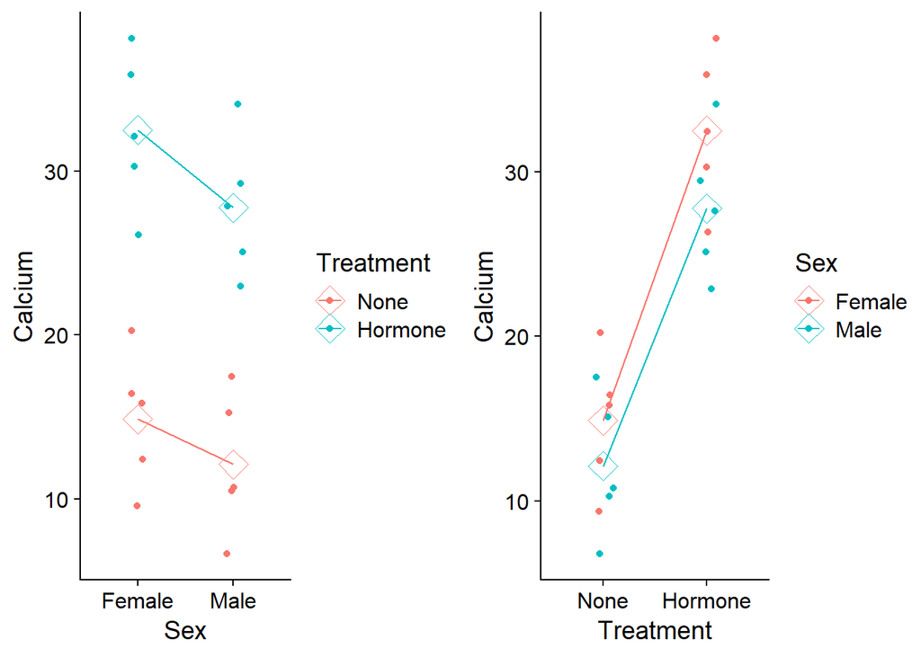

```r
# FIXME
p1  <- ggplot(M, aes(x = Sex,
              y = Calcium,
              color = Treatment,
              group = Treatment)) +
  geom_point(position = position_jitter(width = 0.1)) +
  stat_summary(fun = mean, geom = "point", pch = 5, size = 5) +
  stat_summary(fun = mean, geom = "line")

p2 <- ggplot(M, aes(x = Treatment,
              y = Calcium,
              color = Sex,
              group = Sex)) +
  geom_point(position = position_jitter(width = 0.1)) +
  stat_summary(fun = mean, geom = "point", pch = 5, size = 5) +
  stat_summary(fun = mean, geom = "line")
cowplot::plot_grid(p1, p2, ncol = 2)
```

What do you learn from these plots?

> Hormone almost certainly has a strong positive effect – the lines are very far apart in the first plot. Sexes appear not to differ that much, because the elevations of the lines in the second plot are very similar. Both sexes appear to respond in the same direction and with the same magnitude.

Fit a factorial linear model (both main effects and the interaction term) and save the result to an R object.

```r
# FIXME
fm <- lm(Calcium ~ Sex * Treatment, data = M)
```

Using the `summary()` function, determine the R<sup>2</sup> for the linear model.

```r
# FIXME
summary(fm)
```

```
##
## Call:
## lm(formula = Calcium ~ Sex * Treatment, data = M)
##
## Residuals:
##    Min     1Q Median     3Q    Max
## -6.320 -2.555 -0.100  3.205  6.220
##
## Coefficients:
##                          Estimate Std. Error t value Pr(>|t|)
## (Intercept)                14.880      1.941   7.666 9.60e-07 ***
## SexMale                    -2.760      2.745  -1.005    0.330
## TreatmentHormone           17.640      2.745   6.426 8.38e-06 ***
## SexMale:TreatmentHormone   -1.980      3.882  -0.510    0.617
## ---
## Signif. codes:  0 '***' 0.001 '**' 0.01 '*' 0.05 '.' 0.1 ' ' 1
##
## Residual standard error: 4.34 on 16 degrees of freedom
## Multiple R-squared:  0.829,  Adjusted R-squared:  0.797
## F-statistic: 25.86 on 3 and 16 DF,  p-value: 2.246e-06
```

How much of the variance in calcium level can be explained by the predictors?

> About 83% of the variance in calcium level is explained by Sex, Treatment, and the Sex by Treatment interaction. 17% of the variance remains unexplained.

Using the `Anova()` function in the `car` package, calculate an ANOVA table with type III sums of squares. You might have to install `car` first.

```r
# FIXME
Anova(fm, type = "III")
```

```
## Anova Table (Type III tests)
##
## Response: Calcium
##                Sum Sq Df F value    Pr(>F)
## (Intercept)   1107.07  1 58.7711 9.596e-07 ***
## Sex             19.04  1  1.0110    0.3296
## Treatment      777.92  1 41.2977 8.378e-06 ***
## Sex:Treatment    4.90  1  0.2602    0.6170
## Residuals      301.39 16
## ---
## Signif. codes:  0 '***' 0.001 '**' 0.01 '*' 0.05 '.' 0.1 ' ' 1
```

The package [`sjPlot`](https://strengejacke.github.io/sjPlot/index.html) has lots of useful functions for making tables and plotting regression results. You will probably need to install this package before you use it.

Spend a few minutes looking at the documentation/examples online. An alternative is the [gtsummary](http://www.danieldsjoberg.com/gtsummary/) package.

Use the `tab_model()` function from `sjPlot` to crate a publication-style ANOVA table for the model. Be sure to pass the original model fit object (from `lm()`,) rather than the `Anova()` object.

There are a lot of options for this function. Start with the defaults and change it as you see fit. Include whatever regression information you want.

|  | Calcium |  |  |
| --- | --- | --- | --- |
| Predictors | Estimates | 95% CI | p |
| (Intercept) | 14.88 | 10.77 – 18.99 | **<0.01** |
| Sex [Male] | -2.76 | -8.58 – 3.06 | 0.33 |
| Treatment [Hormone] | 17.64 | 11.82 – 23.46 | **<0.01** |
| Sex [Male] × Treatment [Hormone] | -1.98 | -10.21 – 6.25 | 0.62 |
| Observations | 20 |  |  |
| R<sup>2</sup> / R<sup>2</sup> adjusted | 0.829 / 0.797 |  |  |

Describe the results of the analysis, writing a brief paragraph describing the goal of the analysis, what analysis was carried out, and the results. This is similar to how you would write part of an abstract.

> To determine the relative roles of sex and hormone treatment on blood plasma calcium concentration, we used a 2 X 2 factorial design (*n* = 5 in each group). Factorial ANOVA with the interaction between sex and hormone treatment was analyzed using type III sums of squares. We found a significant effect of hormone treatmen (*F*<sub>1,16</sub> = 41; *P* < 0.001; R<sup>2</sup> = 0.83). Sexes did not differ after controlling for other effects (*P* = 0.33), including the interaction (*P* = 0.62).

## Effect of predation on zooplankton

The file `Zooplankton.csv` contains data on the concentration of zooplankton in three predator treatment groups (control, low, and high levels of predators in an enclosure). Each of the three treatments were measured in five replicate blocks.

### Activity

Read in the data and convert both Treatment and Block into factors. It is especially important to make sure that Block is a factor, because Blocks are coded 1-5. We need to make sure that R converts them to a model matrix (0’s and 1’s) rather than using them as numeric 1 to 5, because the numbering is arbitrary (“exchangeable” in statistical terminology).

```r
# FIXME
M <- read_csv("../data/Zooplankton.csv", col_types = "cdd") |>
  mutate(Treatment = factor(Treatment),
         Block = factor(Block))
```

Print the data to confirm that each treatment was present in each block.

```r
# FIXME
M
```

```
## # A tibble: 15 × 3
##    Treatment Zooplankton Block
##    <fct>           <dbl> <fct>
##  1 control           4.1 1
##  2 low               2.2 1
##  3 high              1.3 1
##  4 control           3.2 2
##  5 low               2.4 2
##  6 high              2   2
##  7 control           3   3
##  8 low               1.5 3
##  9 high              1   3
## 10 control           2.3 4
## 11 low               1.3 4
## 12 high              1   4
## 13 control           2.5 5
## 14 low               2.6 5
## 15 high              1.6 5
```

This is a very good experimental design, because a multilevel model will allow each block to have it’s own intercept and assess the difference(s) among treatments as a deviation from the block mean.

An alternative experimental design would be if the researcher had used 15 different plots and randomly assigned them to one of the three treatments. This would also work, but the multilevel “block” model is more powerful.

Make two plots, one in which Treatment is on the x-axis and Block is encoded by color, and the second in which Block is on the x-axis and Treatment is encoded by color.

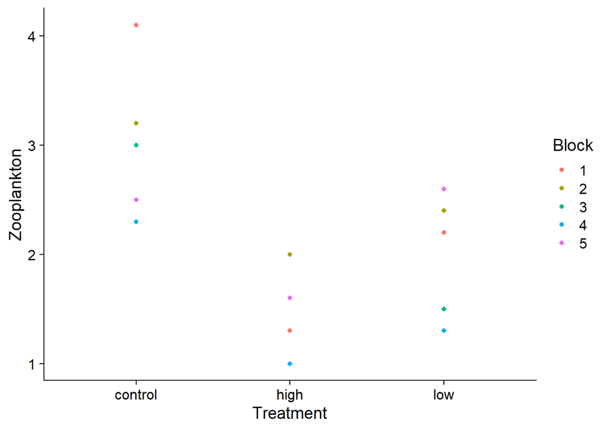

```r
# FIXME
M |>
  ggplot(aes(x = Treatment, y = Zooplankton, color = Block)) +
  geom_point()
```

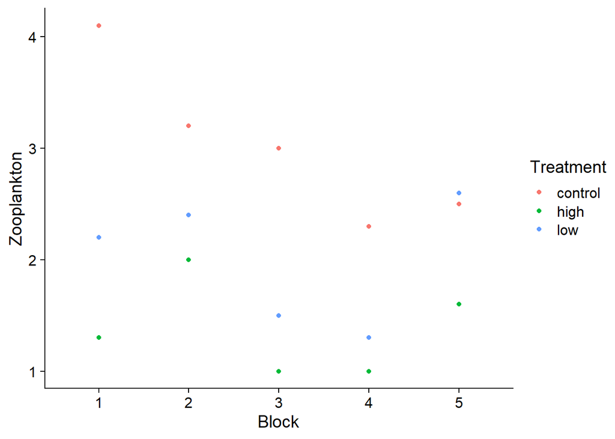

```r
M |>
  ggplot(aes(x = Block, y = Zooplankton, color = Treatment)) +
  geom_point()
```

Notice how you learn different things about the data from each of these plots.

Summarize the mean and standard deviation of each group in a table.

```r
# FIXME
M |>
  group_by(Treatment) |>
  summarize(Mean = mean(Zooplankton),
            `Std. Dev.` = sd(Zooplankton),
            .groups = "drop") |>
  knitr::kable(digits = c(2, 2))
```

| Treatment | Mean | Std. Dev. |
| --- | --- | --- |
| control | 3.02 | 0.70 |
| high | 1.38 | 0.43 |
| low | 2.00 | 0.57 |

We want to test for significant differences in Treatment while accounting for the replicated blocks. We will fit this model using the `lme()` function from the `nlme` package with `Block` as a random effect.

```r
# FIXME
fm_lme <- lme(Zooplankton ~ Treatment,
              random = ~ 1 | Block, M)
```

Now use `anova()` to generate the ANOVA table for the model.

```r
# FIXME
anova(fm_lme)
```

```
##             numDF denDF   F-value p-value
## (Intercept)     1     8 116.69518  <.0001
## Treatment       2     8  16.36595  0.0015
```

Is the overall ANOVA significant? You can determine this by examining the `Treatment` effect (since there is only one predictor).

> Yes, the P-value for Treatment is 0.002.

If the overall ANOVA is significant, all we know is that at least one mean is different from the others. Perform a Tukey’s HSD post-hoc test on the pairwise combinations of all the levels of Treatment.

Refer to Lecture 08-2 for a reminder of how to code Tukey’s HSD with the `multcomp` package.

```r
# FIXME
tukey <- glht(fm_lme, linfct = mcp(Treatment = "Tukey"))
summary(tukey)
```

```
##
##   Simultaneous Tests for General Linear Hypotheses
##
## Multiple Comparisons of Means: Tukey Contrasts
##
##
## Fit: lme.formula(fixed = Zooplankton ~ Treatment, data = M, random = ~1 |
##     Block)
##
## Linear Hypotheses:
##                     Estimate Std. Error z value Pr(>|z|)
## high - control == 0  -1.6400     0.2895  -5.665  < 0.001 ***
## low - control == 0   -1.0200     0.2895  -3.524  0.00121 **
## low - high == 0       0.6200     0.2895   2.142  0.08157 .
## ---
## Signif. codes:  0 '***' 0.001 '**' 0.01 '*' 0.05 '.' 0.1 ' ' 1
## (Adjusted p values reported -- single-step method)
```

Describe the results. Do they make sense biologically?

> Overall there is a significant effect of predator level (P = 0.002). The pairwise post-hoc test shows that both high (P < 0.001) and low (P = 0.001) treatments are significantly different than control, but that high and low are not significantly different from each other (P = 0.08). Strangely, both high and low predation levels are associated with lower levels of zooplankton.

## Grass Species Richness

At the Conard Environmental Research Area (Grinnell, IA), there are 20 experimental plots with 10 burned each fall and 10 left unburned. The following data are grass species richness data from 5 separate, haphazardly chosen, 10 meter<sup>2</sup> plots within each of these 20 experimental plots. The hypothesis to be tested is that burning increases species richness.

```r
# FIXME
set.seed(112)
mms <- c(rnorm(10, 5.5, 2), rnorm(10, 6.5, 2))
all.rich <- numeric(0)
for(ii in mms) {
  all.rich <- c(all.rich, as.integer(rnorm(5, ii, 1)))
}

rich.dat <- data.frame('plot' = as.factor(rep(seq(1, 20), each = 5)),
                       'treatment' = rep(c('burned', 'unburned'), each = 50),
                       'richness' = all.rich)
write.table(rich.dat, file="../data/richness.txt",
            sep="\t", row.names = FALSE)
```

### Activity

Load in the richness data (`richness.txt`), which is a tab-delimited text file (use `read_delim()` and look at the help to determine how to set the field delimiter to tab). Plot species richness vs. treatment. Include an appropriate amount of jitter and transparency and color points by plot.

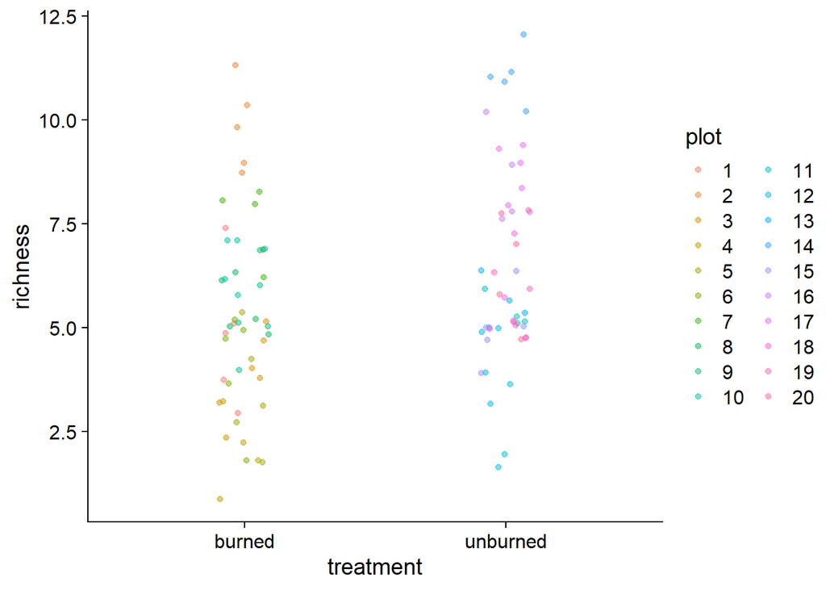

```r
rich.dat <- read_delim("../data/richness.txt",
                       col_types = "dcd",
                       delim = "\t") |>
  mutate(plot = factor(plot))

ggplot(rich.dat, aes(x = treatment, y = richness, color = plot)) +
  geom_point(position = position_jitter(0.1), alpha = 0.5) +
    guides(colour = guide_legend(ncol = 2, byrow = FALSE))
```

Do you think there is a relationship between species richness and burning?

> Probably not. It doesn’t look like a strong relationship.

First, fit a model predicting species richness from treatment without considering plot membership.

```r
anova(lm(richness ~ treatment, data = rich.dat))
```

```
## Analysis of Variance Table
##
## Response: richness
##           Df Sum Sq Mean Sq F value  Pr(>F)
## treatment  1  32.49   32.49  6.0613 0.01556 *
## Residuals 98 525.30    5.36
## ---
## Signif. codes:  0 '***' 0.001 '**' 0.01 '*' 0.05 '.' 0.1 ' ' 1
```

What can you conclude from the results of this model?

> It is difficult to interpret without considering plot as there is pseudoreplication.

Now, calculate the mean species richness value for each plot. Fit a model predicting mean species richness from treatment. This is how you would approach this statistical problem if you did not want to use a multilevel model.

```r
mean.plot <- rich.dat |>
  group_by(plot, treatment) |>
  summarize(meanrich = mean(richness),
            .groups = "drop")
anova(lm(meanrich ~ treatment, data = mean.plot))
```

```
## Analysis of Variance Table
##
## Response: meanrich
##           Df Sum Sq Mean Sq F value Pr(>F)
## treatment  1  6.498   6.498   1.297 0.2697
## Residuals 18 90.180   5.010
```

What can you conclude from this model?

> There is no effect of treatment on species richness.

Use the `lme()` function to fit a model predicting richness from treatment with plot as a random effect.

```r
summary(lme(richness ~ treatment, random = ~1 | plot,
            data = rich.dat))
```

```
## Linear mixed-effects model fit by REML
##   Data: rich.dat
##        AIC      BIC   logLik
##   346.1061 356.4459 -169.053
##
## Random effects:
##  Formula: ~1 | plot
##         (Intercept)  Residual
## StdDev:    2.196361 0.9643651
##
## Fixed effects:  richness ~ treatment
##                   Value Std.Error DF  t-value p-value
## (Intercept)        5.32 0.7078135 80 7.516104  0.0000
## treatmentunburned  1.14 1.0009995 18 1.138862  0.2697
##  Correlation:
##                   (Intr)
## treatmentunburned -0.707
##
## Standardized Within-Group Residuals:
##         Min          Q1         Med          Q3         Max
## -2.76767996 -0.53978614  0.05928632  0.58136355  2.26127497
##
## Number of Observations: 100
## Number of Groups: 20
```

Compare your results to the approach using the mean value. What can you conclude from this model?

> The results are consistent with the model using the mean values. This will not necesarily always happen.

Why would you use `lme()` versus means per group?

> The multilevel model is preferred because it includes all the variation associated with replicate plots. By calculating and using only the means, all the plot-to-plot variation is ignored. Furthermore, there are many patterns of variation than can give the same mean values.

These 20 plots exist in an alternating pattern going from south to north on either side of an access road. What other source of non-independence should you consider? How would you account for this factor?

> The spatial relationship between plots needs to be accounted for. You could include a continuous variable coding for position along the south to north axis and/or side of the road.